# Analysis for Choice Task

Xinyue Li

2/16/2021

# Analysis for Choice Task

Setup and preprocess data

```r
knitr::opts_chunk$set(echo = TRUE)

library(tidyverse)
library(dplyr)
library(lme4)
library(readr)
library(tidyr)
library(ggplot2)
library(sjPlot)
library(sjmisc)
library(Hmisc)
#library(plyr)
library(RColorBrewer)
library(reshape2)

#load raw dataset
dat = read.csv("C:/Users/Christine/Box Sync/data/mem_dm/full_data_dm_3_12.csv")

#create unique id for each subject
dat$ID = cumsum(!duplicated(dat[c('run_id', 'batch_id')]))

code = dat %>% filter(completioncode !='"')
age = dat %>% filter(ttype =='completion')
rating = dat %>% filter(ttype == 'rating_task')

#select and clean choice trials
choice = dat %>% filter(ttype == 'choice_task')
choice = choice %>% filter(rt != "null") %>%
  mutate(rt = as.numeric(rt)) %>%
  mutate(delta.value = as.numeric(value_right) - as.numeric(value_left)) %>%
  mutate(delta.mem = as.numeric(mem_right) - as.numeric(mem_left)) %>%
  mutate(choseright = case_when(key_press == 75 ~ 1, key_press ==74 ~ 0)) %>%
  mutate(abs.mem = abs(delta.mem))

#filter out participants who are 2 sd away from the probability of choosing right/left
choice.prob = choice %>% group_by(ID) %>% dplyr::summarize(right.choice = sum(choseright), right.prob = right.choice/138)
mean.p = mean(choice$choseright)
sd.p = sd(choice.prob$right.prob)
choice.ex.prob = choice.prob %>% filter(abs(right.prob-mean.p)<= 2*sd.p)####
choice = filter(choice, (ID %in% choice.ex.prob$ID))

#filter out participants with RT <300 trials
choice.rtfiltered = choice%>% filter(rt>=300)
choice.rtid =  choice.rtfiltered %>%dplyr::group_by(ID) %>% dplyr::summarise(RT = mean(as.numeric(rt)), n = n())
id.filtered = choice.rtid$ID[choice.rtid$n>=69]
choice = filter(choice.rtfiltered, (ID %in% id.filtered))

#mark trials when participants choose more memorable item
choice = choice %>% mutate(chosehigh.mem = case_when(choseright == 1 & delta.mem >=0 ~ 1, choseright == 0 & delta.mem <0 ~ 1, choseright == 1 & delta.mem <0 ~ 0,choseright == 0 & delta.mem >=0 ~ 0 ))
```

## Exclusion Processes

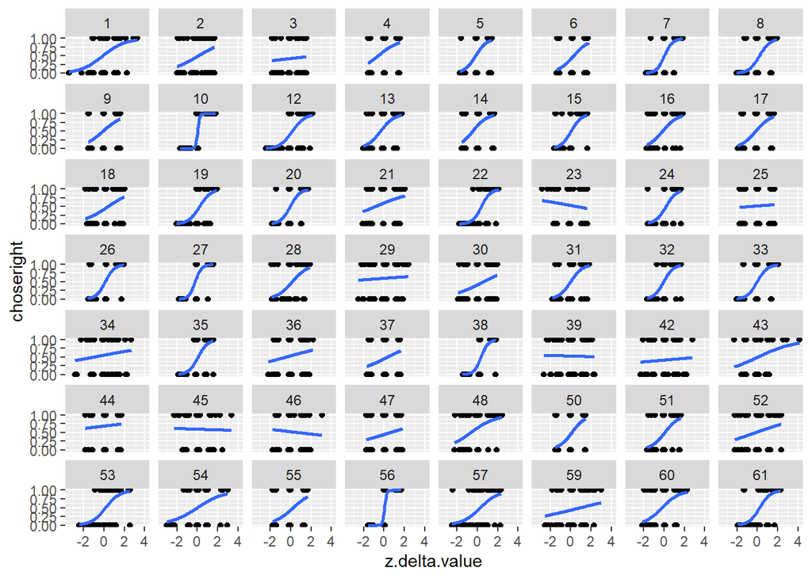

```r
# exclude based on beta in logistical regression
choice.beta = data.frame(ID=double(),
                         beta=double(),
                         p=double(),
                         stringsAsFactors=FALSE)[1:length(id.filtered),]
#calculate beta and p for each subject
for (i in 1:length(id.filtered)) {
  d =  choice %>% filter(ID == id.filtered[i], is.na(choseright)==FALSE)
  logistic = glm(choseright ~ 1 + delta.value, data = d, family = "binomial")
  beta = summary(logistic)[['coefficients']][2,1]
  p = summary(logistic)[['coefficients']][2,4]
  choice.beta$ID[i] = id.filtered[i]
  choice.beta$beta[i] = beta
  choice.beta$p[i] = p
}

filtered.b = choice.beta %>% filter(beta>0, p<0.05)

#plot regression lines in z-scored r
choice = choice %>% dplyr::group_by(ID) %>% dplyr::mutate(z.delta.value = scale(delta.value))
choice %>% group_by(ID) %>% ggplot(aes(x = z.delta.value, y = choseright, group = ID)) +
  geom_point() +
  stat_smooth(method="glm", method.args=list(family="binomial"), se=FALSE)+
  facet_wrap(~ID)
```

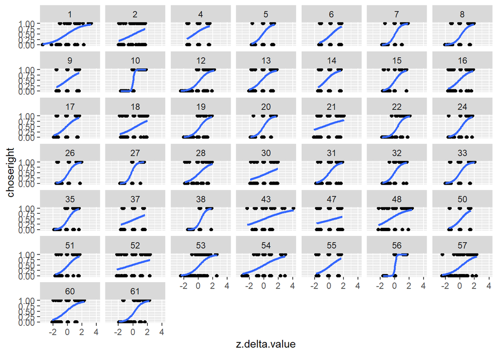

```r
#filter choice with beta >0 and p<0.05
choice = filter(choice, (ID %in% filtered.b$ID | ID %in% c(10, 56)))

#plot regression lines after filtering
choice %>% group_by(ID) %>% ggplot(aes(x = z.delta.value, y = choseright, group = ID)) +
  geom_point() +
  stat_smooth(method="glm", method.args=list(family="binomial"), se=FALSE)+
  facet_wrap(~ID)
```

```r
#write cleaned and exclued data for further use
rating = filter(rating, (ID %in% filtered.b$ID | ID %in% c(10, 56))) %>%
  mutate(response = as.numeric(response)) %>%
  group_by(ID) %>% mutate(z = scale(response))
write.csv(rating, 'C:/Users/Christine/Box Sync/data/mem_dm/cleaned_rating.csv')
write.csv(choice, 'C:/Users/Christine/Box Sync/data/mem_dm/cleaned_choice.csv')
```

## Distribution plots of delta value and delta memorability

These two plots show the distribution of delta memorability (memorability for more memorable item - less memorable item) and the distribution of delta value (value for more memorable item - value for less memorable item), for all choice pairs among participants.

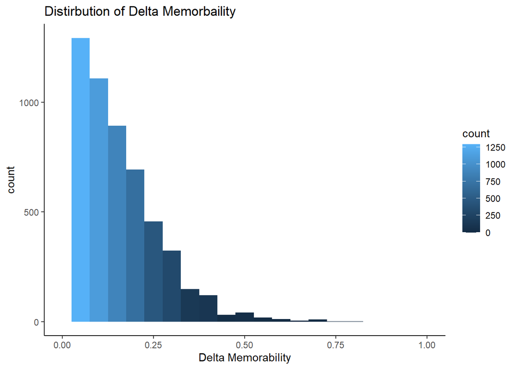

```r
#plot abs delta mem
choice %>% ggplot(aes(x = abs.mem, fill=..count..))+
  geom_histogram(binwidth = 0.05)+
  theme_classic()+
  xlim(0,1)+
  ggtitle('Distirbution of Delta Memorbaility')+
  xlab('Delta Memorability')
```

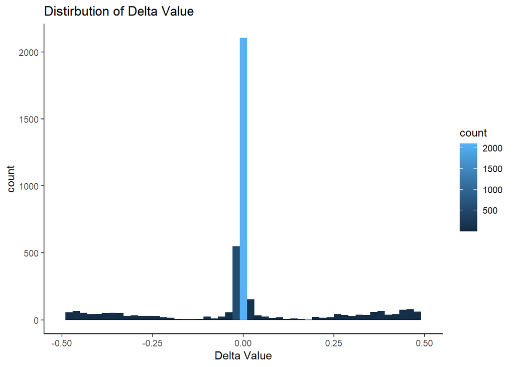

```r
#plot delta value where higher mem - lower mem
choice.memvalue =  choice %>%  mutate(value.highmem = case_when(mem_left >= mem_right ~ -delta.value, mem_left < mem_right ~ delta.value))
choice.memvalue =  choice.memvalue %>%  mutate(value.highmem = value.highmem/100)
choice.memvalue %>% ggplot(aes(x = value.highmem, fill=..count..))+
  geom_histogram(binwidth = 0.02)+
  theme_classic()+
  ggtitle('Distirbution of Delta Value')+
  xlim(-0.5,0.5)+
  xlab('Delta Value')
```

Since we couldn’t find any strong significance of delta memorability on choices, we’re trying to find possible weaker effects. To achieve that we split the trials into high/low delta memorability based on its median within each participant, and compaired the p of choosing higher memorable items within each participant.

```r
library(plyr)
#split trials into high/low delta mem based on within-subject median
choice = choice %>%
  arrange(ID, abs.mem) %>%
  group_by(ID) %>%
  dplyr::mutate(rank = 1:n()) %>%
  ungroup()
choice.low = choice %>% dplyr::group_by(ID) %>% slice(seq(0.5 * n())) %>%
  mutate(bin.absmem = 1)
choice.high = choice %>% dplyr::group_by(ID) %>% slice(-seq(0.5 * n())) %>%
  mutate(bin.absmem = 2)
choice = rbind(choice.high, choice.low)
table(choice$bin.absmem, choice$ID)
```

```
##
##      1  2  4  5  6  7  8  9 10 12 13 14 15 16 17 18 19 20 21 22 24 26 27 28 30
##   1 68 67 69 68 66 67 69 66 68 67 68 62 67 68 69 67 69 69 61 69 59 68 68 69 63
##   2 68 68 69 69 66 67 69 66 68 68 69 63 67 69 69 67 69 69 61 69 60 68 69 69 63
##
##     31 32 33 35 37 38 43 47 48 50 51 52 53 54 55 56 57 60 61
##   1 68 68 68 66 69 68 40 66 69 69 69 69 66 62 65 68 63 68 68
##   2 68 69 68 67 69 69 41 67 69 69 69 69 67 62 66 69 64 69 69
```

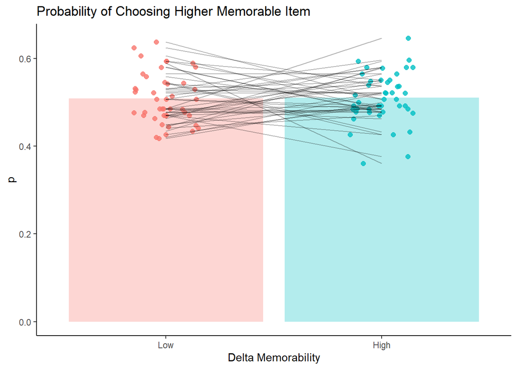

```r
choice = choice %>% mutate(bin.absmem = as.factor(bin.absmem))

#for high/low delta mem plotting
choice.sub = choice %>% group_by(ID, bin.absmem) %>% dplyr::summarize(mem.choice = sum(chosehigh.mem), hmem.p = mem.choice/n())

#plot high/low mem
binned.high.low = choice %>% group_by(bin.absmem) %>% dplyr::summarise(count = sum(chosehigh.mem), mean.mem = mean(abs.mem), n = n(), p = count/n)
binned.high.low = binned.high.low %>% mutate(bin.absmem = as.factor(bin.absmem))
binned.high.image = choice %>% group_by(bin.absmem, ID) %>% dplyr::summarise(count = sum(chosehigh.mem), mean.mem = mean(abs.mem), n = n(), p = count/n)


binned.high.image %>% ggplot(aes( x = bin.absmem, y = p, fill = factor(bin.absmem)))+
  geom_bar(stat="summary", alpha = .3, show.legend = FALSE)+
  geom_point(aes(y = p, color = bin.absmem), position = position_jitter(width = .15), size = 2, alpha = 0.8, show.legend = FALSE) +
  labs(fill='High/Low memorability') +
  theme_classic()+
  ggtitle("Probability of Choosing Higher Memorable Item")+
  geom_line(aes(group = ID),alpha = 0.3)+
  scale_x_discrete(labels=c("1" = "Low", "2" = "High"), name = "Delta Memorability")
```

The raincloud plot for high/low delta memorability differences

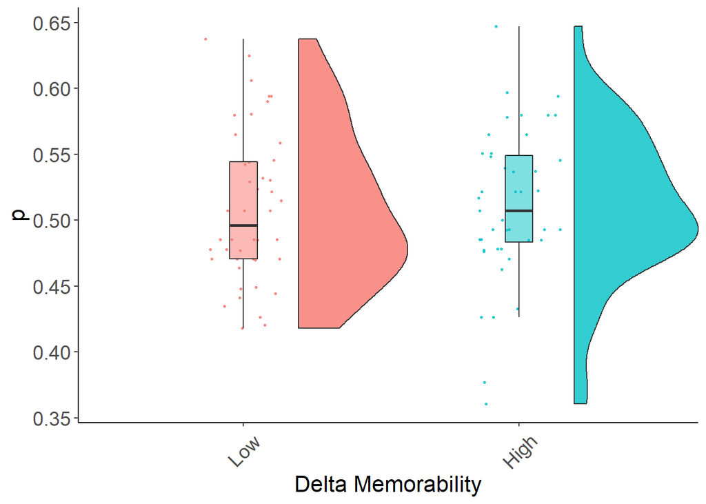

```r
g = ggplot(data = choice.sub, aes(y = hmem.p, x = as.factor(bin.absmem), fill = as.factor(bin.absmem), group=as.factor(bin.absmem))) +
  geom_flat_violin(position = position_nudge(x = .2, y = 0), alpha = .8, show.legend = FALSE) +
  geom_point(aes(y = hmem.p, color = as.factor(bin.absmem)), position = position_jitter(width = .15), size = .5, alpha = 0.8, show.legend = FALSE) +
  geom_boxplot(width = .1, outlier.shape = NA, alpha = 0.5, show.legend = FALSE) +
  #expand_limits(x = 5.25) +
  #guides(fill = FALSE) +
  #guides(color = FALSE) +
  ylab('p')+
  xlim(-1, 2)+
 # labs(fill='High/Low mem') +
  theme_bw() +
 # geom_line(aes(group = ID),alpha = 0.3)+
  scale_x_discrete(labels=c("1" = "Low", "2" = "High"), name = "Delta Memorability")+
  raincloud_theme
g
```

## Model Fitting

Fitted mixted effects model for delta memorability and delta value, and found no effect of delta mem, but strong effect of delta value for predicting the behavior

```r
#mixted effects model for delta mem and delta value
m1 = glmer(choseright~1+delta.mem+delta.value+(1+delta.mem+delta.value|ID), data = choice, family = "binomial")
```

```
## boundary (singular) fit: see ?isSingular
```

```r
summary(m1)
```

```
## Generalized linear mixed model fit by maximum likelihood (Laplace
##   Approximation) [glmerMod]
##  Family: binomial  ( logit )
## Formula:
## choseright ~ 1 + delta.mem + delta.value + (1 + delta.mem + delta.value |
##     ID)
##    Data: choice
##
##      AIC      BIC   logLik deviance df.resid
##   6356.3   6416.4  -3169.2   6338.3     5850
##
## Scaled residuals:
##     Min      1Q  Median      3Q     Max
## -6.4916 -0.9036 -0.1159  0.9116  5.1365
##
## Random effects:
##  Groups Name        Variance  Std.Dev. Corr
##  ID     (Intercept) 0.0480154 0.21912
##         delta.mem   0.0219838 0.14827   0.15
##         delta.value 0.0002147 0.01465  -0.10 -1.00
## Number of obs: 5859, groups:  ID, 44
##
## Fixed effects:
##              Estimate Std. Error z value Pr(>|z|)
## (Intercept) -0.017515   0.045325  -0.386    0.699
## delta.mem   -0.014735   0.171659  -0.086    0.932
## delta.value  0.040410   0.002648  15.259   <2e-16 ***
## ---
## Signif. codes:  0 '***' 0.001 '**' 0.01 '*' 0.05 '.' 0.1 ' ' 1
##
## Correlation of Fixed Effects:
##             (Intr) dlt.mm
## delta.mem    0.027
## delta.value -0.063 -0.127
## optimizer (Nelder_Mead) convergence code: 0 (OK)
## boundary (singular) fit: see ?isSingular
```

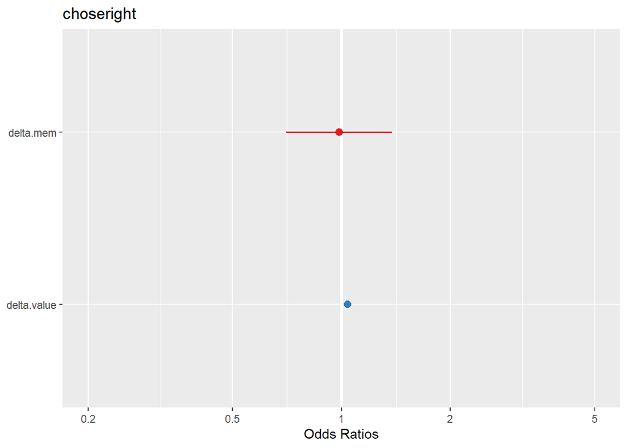

```r
plot_model(m1)
```

```
## Data were 'prettified'. Consider using `terms="delta.mem [all]"` to get smooth plots.
```

```
## Data were 'prettified'. Consider using `terms="delta.value [all]"` to get smooth plots.
```

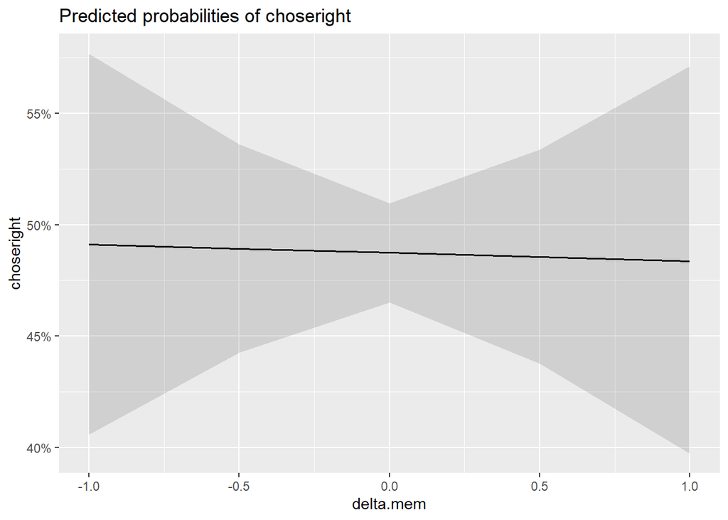

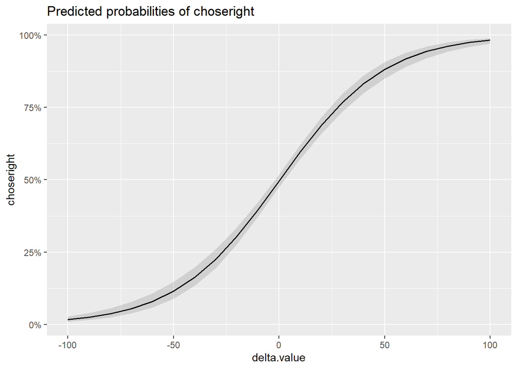

```r
plot_model(m1, type = "pred")
```

Plot for random effects

```r
library(glmmTMB)
```

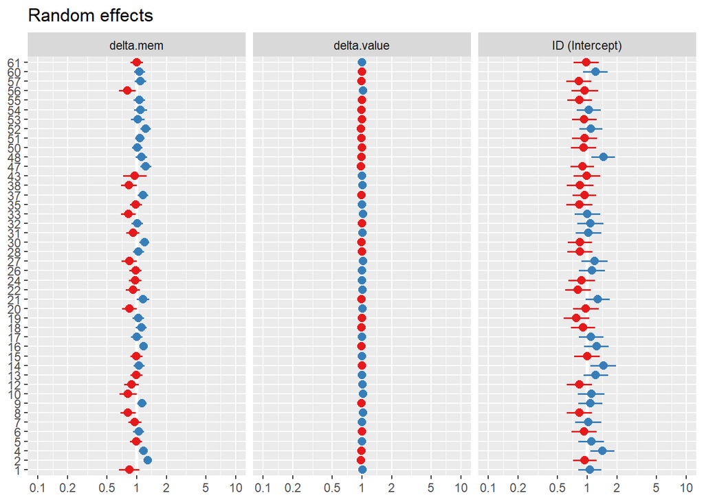

```r
plot_model(m1, type = "re")
```